# Exploratory Data Analysis

load a CSV dataset from a local file using `pandas.read_csv,,, use basic Pandas functions for Exploratory Data Analysis-EDA describe and discriminate between basic data types such as categorical, quantitative, continuous, discrete, ordinal, nominal and identifier

# [Objective 01] LOAD THE DATASET AND EXPLORE

## Overview

Steps for loading a dataset:

1. Learn as much as you can about the dataset:
- Number of rows
- Number of columns
- Column headers (Is there a "data dictionary"?)
- Is there missing data?
- Open the raw file and look at it - it may not be formatted the way you expect.
2. Try loading the dataset using `pandas.read_csv()` and if things aren't acting the way that you expect, investigate until you can get it loading correctly.
3. Keep in mind that functions like `pandas.read_csv()` have a lot of optional parameters that might help us change the way that data is read in. If you get stuck, google, read the documentation, and try things out.
4. You might need to type out column headers by hand if they are not provided in a neat format in the original dataset. It can be a drag.

## Follow Along

### Learn about the dataset and look at the raw file.

### Attempt to load it.

```python
column_headers = ["Id", "SepalLengthCm", "SepalWidthCm",
                  "PetalLengthCm", "PetalWidthCm", "Species"]

# Load dataset with headers
df = pd.read_csv("iris_dirty.csv", names=column_headers, header=None)

# Show first 5 rows
df.head()
```

|  | Id | SepalLengthCm | SepalWidthCm | PetalLengthCm | PetalWidthCm | Species |
| --- | --- | --- | --- | --- | --- | --- |
| 0 | NaN | Sepal.Length | Sepal.Width | Petal.Length | Petal.Width | Species |
| 1 | 1.0 | 5.1 | 3.5 | 1.4 | 0.2 | Setosa |
| 2 | 2.0 | 4.9 | 3 | 1.4 | 0.2 | setosa |
| 3 | 3.0 | 4.7 | 3.2 | 1.3 | 0.2 | setosa |
| 4 | 4.0 | 4.6 | 3.1 | 1.5 | 0.2 | setosa |

```python
import pandas as pd
import numpy as np
import numpy as np
import pandas as pd
import seaborn as sns
import matplotlib.pyplot as plt
import scipy.stats as st
%matplotlib inline

# Load dataset
df = pd.read_csv("iris_dirty.csv")
```

```python
#Print the first 5 rows:
df.head()
```

|  | Unnamed: 0 | Sepal.Length | Sepal.Width | Petal.Length | Petal.Width | Species |
| --- | --- | --- | --- | --- | --- | --- |
| 0 | 1 | 5.1 | 3.5 | 1.4 | 0.2 | Setosa |
| 1 | 2 | 4.9 | 3.0 | 1.4 | 0.2 | setosa |
| 2 | 3 | 4.7 | 3.2 | 1.3 | 0.2 | setosa |
| 3 | 4 | 4.6 | 3.1 | 1.5 | 0.2 | setosa |
| 4 | 5 | NaN | 3.6 | 1.4 | 0.2 | setosa |

```python
#Print the last 5 rows:
df.tail()
```

|  | Unnamed: 0 | Sepal.Length | Sepal.Width | Petal.Length | Petal.Width | Species |
| --- | --- | --- | --- | --- | --- | --- |
| 145 | 146 | 6.7 | 3.0 | 5.2 | 2.3 | virginica |
| 146 | 147 | 6.3 | 2.5 | 5.0 | 1.9 | virginica |
| 147 | 148 | 6.5 | 3.0 | 5.2 | 2.0 | virginica |
| 148 | 149 | 6.2 | 3.4 | 5.4 | 2.3 | virginica |
| 149 | 150 | NaN | 3.0 | 5.1 | 1.8 | virginica |

```python
#Can you print the first 7 rows?
df.head(7)
```

|  | Unnamed: 0 | Sepal.Length | Sepal.Width | Petal.Length | Petal.Width | Species |
| --- | --- | --- | --- | --- | --- | --- |
| 0 | 1 | 5.1 | 3.5 | 1.4 | 0.2 | Setosa |
| 1 | 2 | 4.9 | 3.0 | 1.4 | 0.2 | setosa |
| 2 | 3 | 4.7 | 3.2 | 1.3 | 0.2 | setosa |
| 3 | 4 | 4.6 | 3.1 | 1.5 | 0.2 | setosa |
| 4 | 5 | NaN | 3.6 | 1.4 | 0.2 | setosa |
| 5 | 6 | 5.4 | NaN | 1.7 | 0.4 | setosa |
| 6 | 7 | 4.6 | 3.4 | 1.4 | 0.3 | setosa |

```python
# Shape of dataset
print("Shape of dataset:", df.shape)
```

```
Shape of dataset: (150, 6)
```

```python
# Column names and data types
print("\nInfo:")
print(df.info())
```

```
Info:
<class 'pandas.core.frame.DataFrame'>
RangeIndex: 150 entries, 0 to 149
Data columns (total 6 columns):
 #   Column        Non-Null Count  Dtype
---  ------        --------------  -----
 0   Unnamed: 0    150 non-null    int64
 1   Sepal.Length  142 non-null    float64
 2   Sepal.Width   139 non-null    float64
 3   Petal.Length  150 non-null    float64
 4   Petal.Width   150 non-null    float64
 5   Species       150 non-null    object
dtypes: float64(4), int64(1), object(1)
memory usage: 7.2+ KB
None
```

```python
# Summary statistics for numerical columns
print("\nDescribe:")
print(df.describe())
```

```
Describe:
       Unnamed: 0  Sepal.Length  Sepal.Width  Petal.Length  Petal.Width
count  150.000000    142.000000   139.000000    150.000000   150.000000
mean    75.500000      5.840141     3.043165      3.758000     1.199333
std     43.445368      0.831905     0.438550      1.765298     0.762238
min      1.000000      4.300000     2.000000      1.000000     0.100000
25%     38.250000      5.100000     2.800000      1.600000     0.300000
50%     75.500000      5.800000     3.000000      4.350000     1.300000
75%    112.750000      6.400000     3.300000      5.100000     1.800000
max    150.000000      7.900000     4.400000      6.900000     2.500000
```

```python
# Check missing values
print("\nMissing values:")
print(df.isnull().sum())
```

```
Missing values:
Unnamed: 0       0
Sepal.Length     8
Sepal.Width     11
Petal.Length     0
Petal.Width      0
Species          0
dtype: int64
```

```python
# Unique values for categorical columns
print("\nUnique values for categorical columns:")
for col in df.select_dtypes(include="object").columns:
    print(col, df[col].unique())
```

```
Unique values for categorical columns:
Species ['Setosa' 'setosa' 'SETOSA' 'versicolor' 'Versicolor' 'VERSICOLOR'
 'virginica' 'VIRGINICA']
```

```python
rows, cols = df.shape
print(f"Dimensions of dataset: {rows} rows × {cols} columns")
```

```
Dimensions of dataset: 150 rows × 6 columns
```

# Objective 02 - Use basic Pandas functions for Exploratory Data Analysis (EDA)

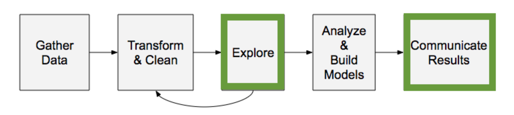

## Overview

> Exploratory Data Analysis (EDA) refers to the critical process of performing initial investigations on data so as to discover patterns, to spot anomalies, to test hypotheses and to check assumptions with the help of summary statistics and graphical representations

Exploratory Data Analysis is often the first thing that we'll do when starting out with a new dataset.

```python
#Learn more about the variables in the dataset using info function
print("\nInfo():")
print(df.info())
```

```
Info():
<class 'pandas.core.frame.DataFrame'>
RangeIndex: 150 entries, 0 to 149
Data columns (total 6 columns):
 #   Column        Non-Null Count  Dtype
---  ------        --------------  -----
 0   Unnamed: 0    150 non-null    int64
 1   Sepal.Length  142 non-null    float64
 2   Sepal.Width   139 non-null    float64
 3   Petal.Length  150 non-null    float64
 4   Petal.Width   150 non-null    float64
 5   Species       150 non-null    object
dtypes: float64(4), int64(1), object(1)
memory usage: 7.2+ KB
None
```

# Learn more about each variable

```python
#Determine the data types
df.dtypes
```

```
Unnamed: 0        int64
Sepal.Length    float64
Sepal.Width     float64
Petal.Length    float64
Petal.Width     float64
Species          object
dtype: object
```

```python
# Summary Statistics - using (describe function)
# check if there are non-numeric column
df.describe()
```

|  | Unnamed: 0 | Sepal.Length | Sepal.Width | Petal.Length | Petal.Width |
| --- | --- | --- | --- | --- | --- |
| count | 150.000000 | 142.000000 | 139.000000 | 150.000000 | 150.000000 |
| mean | 75.500000 | 5.840141 | 3.043165 | 3.758000 | 1.199333 |
| std | 43.445368 | 0.831905 | 0.438550 | 1.765298 | 0.762238 |
| min | 1.000000 | 4.300000 | 2.000000 | 1.000000 | 0.100000 |
| 25% | 38.250000 | 5.100000 | 2.800000 | 1.600000 | 0.300000 |
| 50% | 75.500000 | 5.800000 | 3.000000 | 4.350000 | 1.300000 |
| 75% | 112.750000 | 6.400000 | 3.300000 | 5.100000 | 1.800000 |
| max | 150.000000 | 7.900000 | 4.400000 | 6.900000 | 2.500000 |

```python
df.describe(include='all')
```

|  | Unnamed: 0 | Sepal.Length | Sepal.Width | Petal.Length | Petal.Width | Species |
| --- | --- | --- | --- | --- | --- | --- |
| count | 150.000000 | 142.000000 | 139.000000 | 150.000000 | 150.000000 | 150 |
| unique | NaN | NaN | NaN | NaN | NaN | 8 |
| top | NaN | NaN | NaN | NaN | NaN | virginica |
| freq | NaN | NaN | NaN | NaN | NaN | 49 |
| mean | 75.500000 | 5.840141 | 3.043165 | 3.758000 | 1.199333 | NaN |
| std | 43.445368 | 0.831905 | 0.438550 | 1.765298 | 0.762238 | NaN |
| min | 1.000000 | 4.300000 | 2.000000 | 1.000000 | 0.100000 | NaN |
| 25% | 38.250000 | 5.100000 | 2.800000 | 1.600000 | 0.300000 | NaN |
| 50% | 75.500000 | 5.800000 | 3.000000 | 4.350000 | 1.300000 | NaN |
| 75% | 112.750000 | 6.400000 | 3.300000 | 5.100000 | 1.800000 | NaN |
| max | 150.000000 | 7.900000 | 4.400000 | 6.900000 | 2.500000 | NaN |

```python
# try to exclude non numeric value
df.select_dtypes(include=['object']).columns
```

```
Index(['Species'], dtype='object')
```

```python
# include all

df['Species'].value_counts()
```

```
Species
virginica     49
setosa        48
versicolor    48
Setosa         1
SETOSA         1
Versicolor     1
VERSICOLOR     1
VIRGINICA      1
Name: count, dtype: int64
```

```python
# accesss a specific column of the dataframe
# Access 'Species' column
print(df['Species'].head())

# Value counts for 'Species' column
print(df['Species'].value_counts())
```

```
0    Setosa
1    setosa
2    setosa
3    setosa
4    setosa
Name: Species, dtype: object
Species
virginica     49
setosa        48
versicolor    48
Setosa         1
SETOSA         1
Versicolor     1
VERSICOLOR     1
VIRGINICA      1
Name: count, dtype: int64
```

```python
#sort by values (any specific column)
df.sort_values(by="Sepal.Length").head()
```

|  | Unnamed: 0 | Sepal.Length | Sepal.Width | Petal.Length | Petal.Width | Species |
| --- | --- | --- | --- | --- | --- | --- |
| 13 | 14 | 4.3 | 3.0 | 1.1 | 0.1 | setosa |
| 42 | 43 | 4.4 | 3.2 | 1.3 | 0.2 | setosa |
| 38 | 39 | 4.4 | 3.0 | 1.3 | 0.2 | setosa |
| 8 | 9 | 4.4 | 2.9 | 1.4 | 0.2 | setosa |
| 41 | 42 | 4.5 | 2.3 | 1.3 | 0.3 | setosa |

```python
# check for missing values
# the number of missing values in each column
df.isnull()
```

|  | Unnamed: 0 | Sepal.Length | Sepal.Width | Petal.Length | Petal.Width | Species |
| --- | --- | --- | --- | --- | --- | --- |
| 0 | False | False | False | False | False | False |
| 1 | False | False | False | False | False | False |
| 2 | False | False | False | False | False | False |
| 3 | False | False | False | False | False | False |
| 4 | False | True | False | False | False | False |
| ... | ... | ... | ... | ... | ... | ... |
| 145 | False | False | False | False | False | False |
| 146 | False | False | False | False | False | False |
| 147 | False | False | False | False | False | False |
| 148 | False | False | False | False | False | False |
| 149 | False | True | False | False | False | False |

150 rows × 6 columns

```python
df.isnull().sum()
```

```
Unnamed: 0       0
Sepal.Length     8
Sepal.Width     11
Petal.Length     0
Petal.Width      0
Species          0
dtype: int64
```

```python
df.isnull().sum().sum()
```

```
np.int64(19)
```

```python
# Total number of missing cells in the entire dataset
total_missing = df.isnull().sum().sum()
print("Total missing cells in dataset:", total_missing)
```

```
Total missing cells in dataset: 19
```

```python
# try dropping rows from the dataset inplace
df.dropna(inplace=True)
```

```python
# axis=1 to look through column headers and not row index
#Drop ID variable
df.drop("Sepal.Length", axis=1, inplace=True)

#inplace
#drop(column_name, axis=1, inplace=True)# Columns gets removed
```

Recap - what do each of these things do???

- df.shape
- df.head()
- df.dtypes
- df.describe()
- Numeric
- Non-Numeric
- df['column'].value_counts()
- df.isnull().sum()
- df.isnull().sum().sum()
- df.drop()

# Objective 03 Describe and discriminate between basic data types

## Overview

One of the cornerstones of Exploratory Data Analysis (EDA) is being able to identify variable types. We will need different statistical methods to display and describe each of these different types of data.

```python
df = pd.read_csv("iris_dirty.csv", names=column_headers, header=None)
df.head()
```

|  | Id | SepalLengthCm | SepalWidthCm | PetalLengthCm | PetalWidthCm | Species |
| --- | --- | --- | --- | --- | --- | --- |
| 0 | NaN | Sepal.Length | Sepal.Width | Petal.Length | Petal.Width | Species |
| 1 | 1.0 | 5.1 | 3.5 | 1.4 | 0.2 | Setosa |
| 2 | 2.0 | 4.9 | 3 | 1.4 | 0.2 | setosa |
| 3 | 3.0 | 4.7 | 3.2 | 1.3 | 0.2 | setosa |
| 4 | 4.0 | 4.6 | 3.1 | 1.5 | 0.2 | setosa |

```python
df.select_dtypes(include=[np.number]).skew()
print(df.head())
```

```
    Id SepalLengthCm SepalWidthCm PetalLengthCm PetalWidthCm  Species
0  NaN  Sepal.Length  Sepal.Width  Petal.Length  Petal.Width  Species
1  1.0           5.1          3.5           1.4          0.2   Setosa
2  2.0           4.9            3           1.4          0.2   setosa
3  3.0           4.7          3.2           1.3          0.2   setosa
4  4.0           4.6          3.1           1.5          0.2   setosa
```

```python
df = df[df["SepalWidthCm"] != "Sepal.Width"].reset_index(drop=True)
```

```python
df["SepalWidthCm"] = pd.to_numeric(df["SepalWidthCm"], errors="coerce")
```

```python
print(df["SepalWidthCm"].skew())
```

```
0.3406404145264381
```

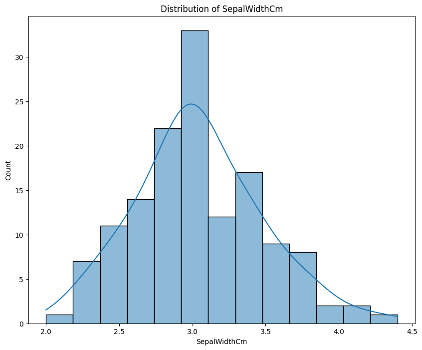

```python
plt.figure(figsize= (10,8))
sns.histplot(df["SepalWidthCm"], kde=True)
plt.title("Distribution of SepalWidthCm")
plt.show()
```

```python
df["SepalWidthCm"].kurt()
```

```
np.float64(0.27127989325185053)
```

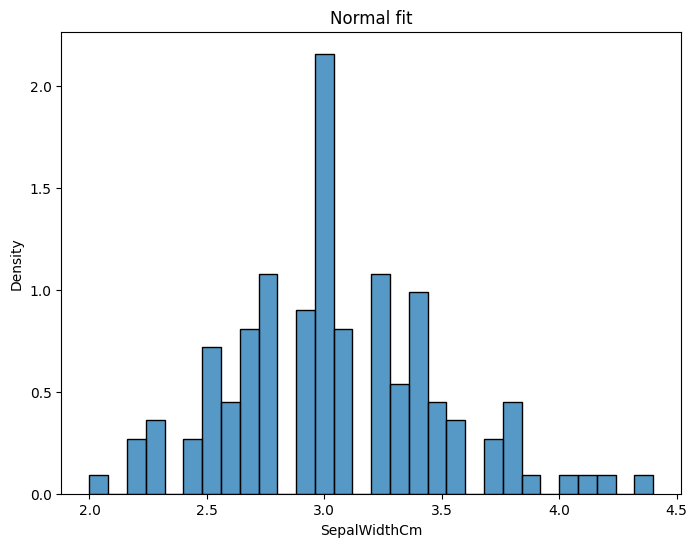

```python
y = df['SepalWidthCm']
plt.figure(figsize=(8,6))
sns.histplot(y, kde=False, stat="density", bins=30)
plt.title('Normal fit')
plt.show()
```

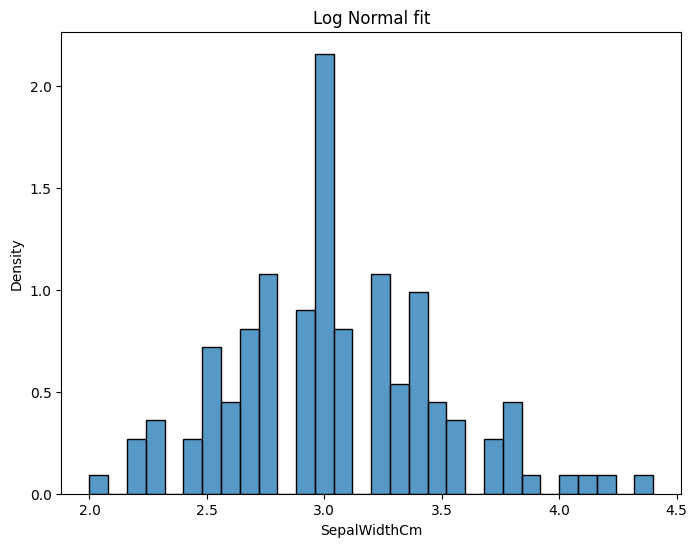

```python
plt.figure(figsize=(8,6))
sns.histplot(y, kde=False, stat="density", bins=30)
plt.title('Log Normal fit')
plt.show()
```

```python
df['Species'].value_counts()
```

```
Species
virginica     49
setosa        48
versicolor    48
Setosa         1
SETOSA         1
Versicolor     1
VERSICOLOR     1
VIRGINICA      1
Name: count, dtype: int64
```

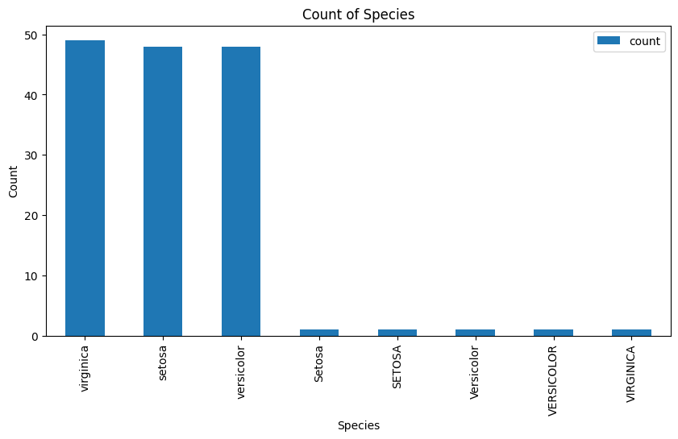

```python
df['Species'].value_counts().plot(kind = 'bar', figsize=(10,5))
plt.title('Count of Species')
plt.xlabel('Species')
plt.ylabel('Count')
plt.legend()
plt.show()
```

```python
num_cols = ["SepalLengthCm", "SepalWidthCm", "PetalLengthCm", "PetalWidthCm"]
df[num_cols] = df[num_cols].apply(pd.to_numeric, errors="coerce")
```

```python
corr_matrix = df[num_cols].corr()
print(corr_matrix)
```

```
               SepalLengthCm  SepalWidthCm  PetalLengthCm  PetalWidthCm
SepalLengthCm       1.000000     -0.096690       0.872044      0.817492
SepalWidthCm       -0.096690      1.000000      -0.406541     -0.342267
PetalLengthCm       0.872044     -0.406541       1.000000      0.962865
PetalWidthCm        0.817492     -0.342267       0.962865      1.000000
```

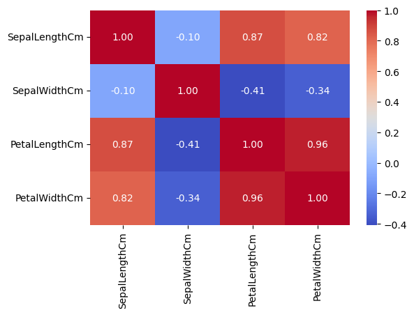

```python
import matplotlib.pyplot as plt
import seaborn as sns

plt.figure(figsize=(6,4))
sns.heatmap(corr_matrix, annot=True, cmap="coolwarm", fmt=".2f")
plt.show()
```

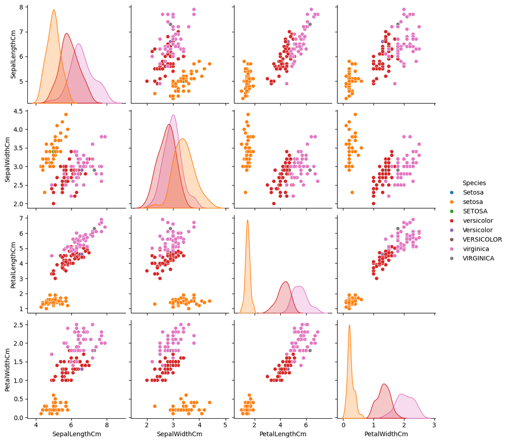

```python
import seaborn as sns
import matplotlib.pyplot as plt

# Pick the useful columns
num_cols = ["SepalLengthCm", "SepalWidthCm", "PetalLengthCm", "PetalWidthCm"]

# Pairplot with species as hue (color by species)
sns.pairplot(df[num_cols + ["Species"]], hue="Species")
```

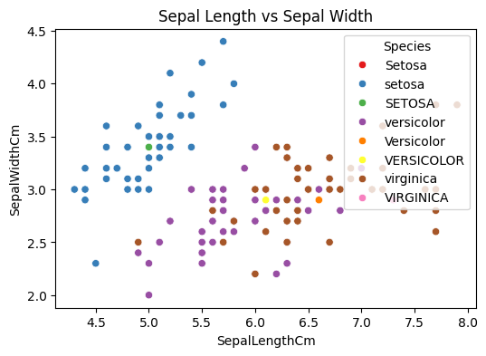

```python
import seaborn as sns
import matplotlib.pyplot as plt

plt.figure(figsize=(6,4))
sns.scatterplot(
    data=df,
    x="SepalLengthCm",
    y="SepalWidthCm",
    hue="Species",
    palette="Set1"
)
plt.title("Sepal Length vs Sepal Width")
plt.show()
```

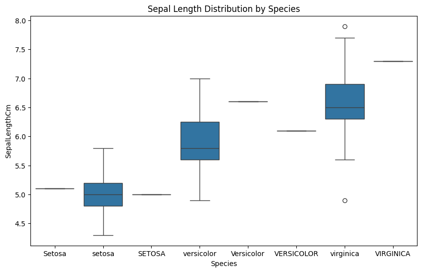

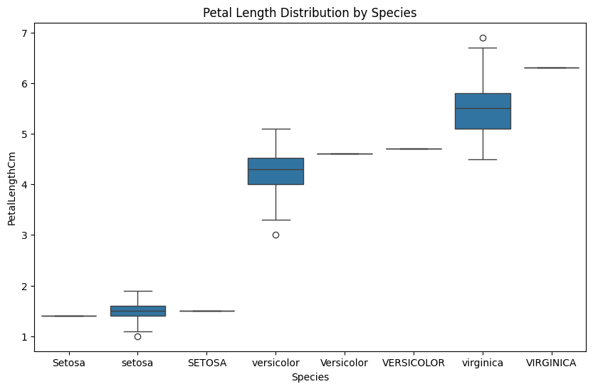

```python
plt.figure(figsize=(10,6))
sns.boxplot(data=df, x="Species", y="SepalLengthCm")
plt.title("Sepal Length Distribution by Species")
plt.show()

plt.figure(figsize=(10,6))
sns.boxplot(data=df, x="Species", y="PetalLengthCm")
plt.title("Petal Length Distribution by Species")
plt.show()
```

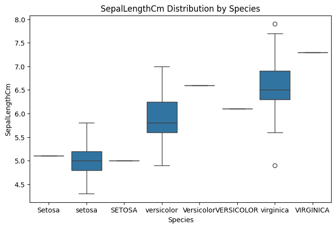

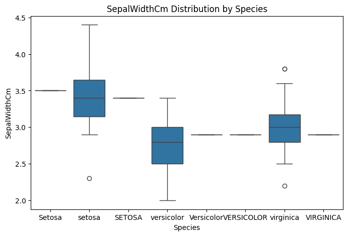

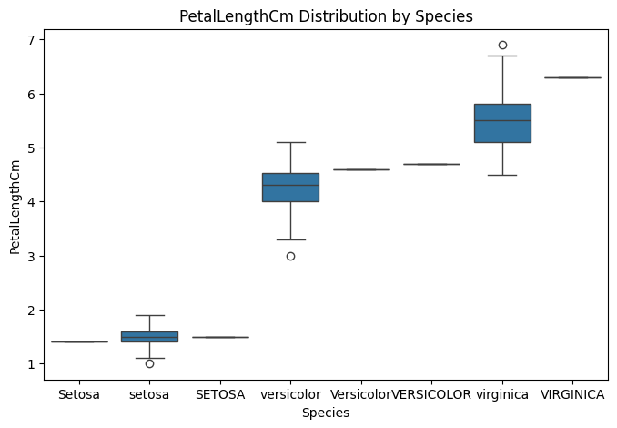

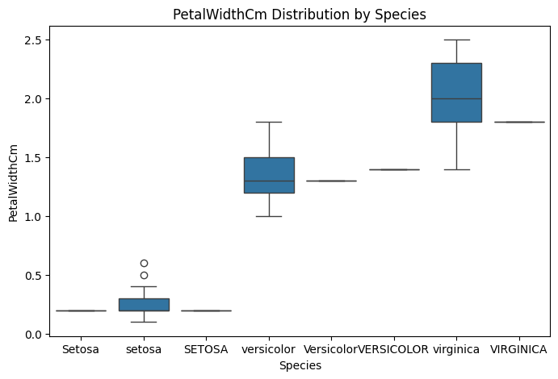

```python
num_cols = ["SepalLengthCm", "SepalWidthCm", "PetalLengthCm", "PetalWidthCm"]

for col in num_cols:
    plt.figure(figsize=(8,5))
    sns.boxplot(data=df, x="Species", y=col)
    plt.title(f"{col} Distribution by Species")
    plt.show()
```